# R Notebook

# Argus Media - Conding Test

## Ivan Berlim Gonçalves

The purpose of this exercise is to design and implement an entire data preparation pipeline in R. We would like you to implement a robust, extensible and generic framework for data preparation.

#### Packages and Libraries

```r
# Verify if the package is already installed, if not, install package
packages <- c("gamlss", "gamlss.add", "gamlss.dist", "roll", "dplyr", "tseries", "ggpubr", "magrittr", "labelVector", "corrplot", "Hmisc")
install.packages(setdiff(packages, rownames(installed.packages())))

# Loading libraries
library(gamlss)
library(gamlss.add)
library(gamlss.dist)
# library(DT)
library(roll)
library(dplyr)
# library(stats)
library(ggpubr)
library(tseries)
# library(ggplot2)
# library(dataspice)
library(Hmisc)
library(magrittr)
library(labelVector)
library(corrplot)
```

1. Take as raw inputs to the data preparation process, the oil data from the gamlss package.

```r
# Raw data preparation
data_prep <- function(rawdata) {
  oil_data <- rawdata
  return(oil_data)
}

oil_data <- data_prep(gamlss.data::oil)

# Printing data information
paste0("The data set has ", nrow(oil_data), " observations and  ", ncol(oil_data), " variables. ")
```

```
## [1] "The data set has 1000 observations and  25 variables. "
```

```r
cat('\n')
```

```r
oil_col_names <- colnames(oil_data)
cat('Columns in the data frame: \n\n')
```

```
## Columns in the data frame:
```

```r
for (i in (1:ncol(oil))) {print(paste0("Column number: ",i, ". Variable name: ", oil_col_names[i]))}
```

```
## [1] "Column number: 1. Variable name: OILPRICE"
## [1] "Column number: 2. Variable name: CL2_log"
## [1] "Column number: 3. Variable name: CL3_log"
## [1] "Column number: 4. Variable name: CL4_log"
## [1] "Column number: 5. Variable name: CL5_log"
## [1] "Column number: 6. Variable name: CL6_log"
## [1] "Column number: 7. Variable name: CL7_log"
## [1] "Column number: 8. Variable name: CL8_log"
## [1] "Column number: 9. Variable name: CL9_log"
## [1] "Column number: 10. Variable name: CL10_log"
## [1] "Column number: 11. Variable name: CL11_log"
## [1] "Column number: 12. Variable name: CL12_log"
## [1] "Column number: 13. Variable name: CL13_log"
## [1] "Column number: 14. Variable name: CL14_log"
## [1] "Column number: 15. Variable name: CL15_log"
## [1] "Column number: 16. Variable name: BDIY_log"
## [1] "Column number: 17. Variable name: SPX_log"
## [1] "Column number: 18. Variable name: DX1_log"
## [1] "Column number: 19. Variable name: GC1_log"
## [1] "Column number: 20. Variable name: HO1_log"
## [1] "Column number: 21. Variable name: USCI_log"
## [1] "Column number: 22. Variable name: GNR_log"
## [1] "Column number: 23. Variable name: SHCOMP_log"
## [1] "Column number: 24. Variable name: FTSE_log"
## [1] "Column number: 25. Variable name: respLAG"
```

2. Develop a process that allows us to add additional drivers which are transformations of the raw input timeseries. Include the following transformations:
1. Rolling standard deviation (of arbitrary window)
2. Rolling mean (of arbitrary window)
3. Lagging (of arbitrary order)
4. Leading (of arbitrary order)
5. Differencing
6. Spread (between two input drivers)
7. Ratio (between two input drivers)
8. Product (between two input drivers)
- Function `data_trans` includes:

roll_std_dev (Rolling standard deviation) - 7 days selected roll_mean (Rolling mean) - 7 days selected lag_1 (Lagging) - order 1 selected lead (Leading) - order 1 selected diff (Differencing)

```r
data_trans <- function(raw_data_1) {

  # add input driver to dataframe
  df_1 <- as.data.frame(raw_data_1)
  oil_data_1 <- raw_data_1
  oil_data_1 <- as.matrix(oil_data_1)

  # Rolling standard deviation, window = 7
  roll_std_dev <- roll::roll_sd(oil_data_1, 7)
  df_1$roll_std_dev <- roll_std_dev

  # Rolling mean, window = 7
  roll_mean <- roll::roll_mean(oil_data_1, 7)
  df_1$roll_mean <- roll_mean

  # Lagging, order = 1
  df_1$lag_1 <- dplyr::lag(raw_data_1)

  # Leading, order = 1
  df_1$lead <- dplyr::lead(raw_data_1)

  # Differencing
  Diff <- raw_data_1 %>% diff()
  Diff[1000] <- NA
  df_1$diff <- Diff

  return(df_1)
}

oil_data_trans <- data_trans(oil_data$OILPRICE)
head(oil_data_trans, n =10)
```

|  | raw_data_1 | roll_std_dev | roll_mean | lag_1 | lead | diff |
| --- | --- | --- | --- | --- | --- | --- |
| 1 | 4.640923 | NA | NA | NA | 4.633077 | -0.0078462165 |
| 2 | 4.633077 | NA | NA | 4.640923 | 4.634049 | 0.0009720063 |
| 3 | 4.634049 | NA | NA | 4.633077 | 4.646312 | 0.0122629838 |
| 4 | 4.646312 | NA | NA | 4.634049 | 4.631520 | -0.0147921680 |
| 5 | 4.631520 | NA | NA | 4.646312 | 4.627616 | -0.0039035865 |
| 6 | 4.627616 | NA | NA | 4.631520 | 4.635214 | 0.0075979325 |
| 7 | 4.635214 | 0.006223043 | 4.635530 | 4.627616 | 4.635796 | 0.0005820722 |
| 8 | 4.635796 | 0.005767563 | 4.634798 | 4.635214 | 4.640055 | 0.0042582083 |
| 9 | 4.640055 | 0.006018100 | 4.635795 | 4.635796 | 4.645544 | 0.0054894923 |
| 10 | 4.645544 | 0.006957400 | 4.637437 | 4.640055 | 4.649665 | 0.0041213457 |

You can pass any dataframe column to the function. It will calculate all the compositions

- Building another function called `data_trans_2` to deal with 2 drivers. It contains the Ration and Product. I couldn’t solve the spread between two input drivers. Maybe I needed more time to invest in a satisfatory answer.
6. Spread (between two input drivers)
7. Ratio (between two input drivers)
8. Product (between two input drivers)

```r
data_trans_2 <- function(raw_data_2){

  # add input driver to dataframe
  df_2 <- as.data.frame(raw_data_2)

  # Ratio bet
  df_2$Ratio <- df_2[,1]/df_2[,2]

  # Product
  df_2$Product <- df_2[,1] * df_2[,2]

  return(df_2)
}

df_2 <- data_trans_2(oil_data[, c("OILPRICE", "respLAG")])
head(df_2, n = 10)
```

|  | OILPRICE | respLAG | Ratio | Product |
| --- | --- | --- | --- | --- |
| 1 | 4.640923 | 4.631812 | 1.0019671 | 21.49589 |
| 2 | 4.633077 | 4.640923 | 0.9983093 | 21.50176 |
| 3 | 4.634049 | 4.633077 | 1.0002098 | 21.46991 |
| 4 | 4.646312 | 4.634049 | 1.0026463 | 21.53124 |
| 5 | 4.631520 | 4.646312 | 0.9968164 | 21.51949 |
| 6 | 4.627616 | 4.631520 | 0.9991572 | 21.43290 |
| 7 | 4.635214 | 4.627616 | 1.0016419 | 21.44999 |
| 8 | 4.635796 | 4.635214 | 1.0001256 | 21.48791 |
| 9 | 4.640055 | 4.635796 | 1.0009185 | 21.51035 |
| 10 | 4.645544 | 4.640055 | 1.0011831 | 21.55558 |

You can pass any dataframe column to the function. It will calculate the ratio and the product between the two columns

3. We must be able to have composition of transformations. Example: First calculate the difference between OILPRICE and resp_LAG, and then calculate the rolling standard deviation.
- Building `data_composition` function. This also works with two columns.

```r
data_composition <- function(raw_data_3){

  # add input driver to dataframe
  df_3 <- as.data.frame(raw_data_3)

  # Difference
  difference <- (df_3$OILPRICE - df_3$respLAG)
  df_3$difference <- difference
  difference <- as.matrix(difference)

  # Rolling standard deviation, window = 7
  roll_std <- roll::roll_sd(difference, 7)
  df_3$roll_std <- roll_std

  return(df_3)
}

df_3 <- data_composition(oil_data[,c("OILPRICE", "respLAG")])

head(df_3, n = 10)
```

|  | OILPRICE | respLAG | difference | roll_std |
| --- | --- | --- | --- | --- |
| 1 | 4.640923 | 4.631812 | 0.0091112388 | NA |
| 2 | 4.633077 | 4.640923 | -0.0078462165 | NA |
| 3 | 4.634049 | 4.633077 | 0.0009720063 | NA |
| 4 | 4.646312 | 4.634049 | 0.0122629838 | NA |
| 5 | 4.631520 | 4.646312 | -0.0147921680 | NA |
| 6 | 4.627616 | 4.631520 | -0.0039035865 | NA |
| 7 | 4.635214 | 4.627616 | 0.0075979325 | 0.009882852 |
| 8 | 4.635796 | 4.635214 | 0.0005820722 | 0.009140087 |
| 9 | 4.640055 | 4.635796 | 0.0042582083 | 0.008704563 |
| 10 | 4.645544 | 4.640055 | 0.0054894923 | 0.008868343 |

```r
final_drivers <- cbind(oil_data_trans, df_2, df_3)
final_drivers <-
  final_drivers[, c("raw_data_1", "roll_std_dev", "roll_mean",
                       "lag_1", "lead", "diff", "Ratio", "Product",
                       "roll_std")]

head(final_drivers, n = 10)
```

|  | raw_data_1 | roll_std_dev | roll_mean | lag_1 | lead | diff | Ratio | Product | roll_std |
| --- | --- | --- | --- | --- | --- | --- | --- | --- | --- |
| 1 | 4.640923 | NA | NA | NA | 4.633077 | -0.0078462165 | 1.0019671 | 21.49589 | NA |
| 2 | 4.633077 | NA | NA | 4.640923 | 4.634049 | 0.0009720063 | 0.9983093 | 21.50176 | NA |
| 3 | 4.634049 | NA | NA | 4.633077 | 4.646312 | 0.0122629838 | 1.0002098 | 21.46991 | NA |
| 4 | 4.646312 | NA | NA | 4.634049 | 4.631520 | -0.0147921680 | 1.0026463 | 21.53124 | NA |
| 5 | 4.631520 | NA | NA | 4.646312 | 4.627616 | -0.0039035865 | 0.9968164 | 21.51949 | NA |
| 6 | 4.627616 | NA | NA | 4.631520 | 4.635214 | 0.0075979325 | 0.9991572 | 21.43290 | NA |
| 7 | 4.635214 | 0.006223043 | 4.635530 | 4.627616 | 4.635796 | 0.0005820722 | 1.0016419 | 21.44999 | 0.009882852 |
| 8 | 4.635796 | 0.005767563 | 4.634798 | 4.635214 | 4.640055 | 0.0042582083 | 1.0001256 | 21.48791 | 0.009140087 |
| 9 | 4.640055 | 0.006018100 | 4.635795 | 4.635796 | 4.645544 | 0.0054894923 | 1.0009185 | 21.51035 | 0.008704563 |
| 10 | 4.645544 | 0.006957400 | 4.637437 | 4.640055 | 4.649665 | 0.0041213457 | 1.0011831 | 21.55558 | 0.008868343 |

5. For all drivers, either in their raw form or those that results from the application of one or several transformations, we must keep a meta data object where the sequence of transformations is stored. This will allow us to keep track of the meaning of each new driver. Combine all the drivers from their raw form or those that result from the application of one or several transformations using cbind(), named dataset as final_drivers.
- Creating meta data object:

```r
# labeling the variables
print_with_label <- function(dframe){
  stopifnot(inherits(dframe, "data.frame"))
  labs <- labelVector::get_label(dframe, names(dframe))
  labs <- sprintf("%s: %s", names(dframe), labs)
  #print(dframe)
  cat("\n")
  cat(labs, sep = "\n")
}
final_drivers <-set_label(final_drivers,
                             raw_data_1 = "target variable",
                             roll_std_dev = "Rolling standard deviation(window = 7)",
                             roll_std = "Rolling standard deviation(window = 7)",
                             roll_mean = "Rolling mean (window = 7)",
                             lag_1 = "Lagging (order = 1)",
                             lead = "Leading (order = 1)",
                             diff = "Differencing (order = 1)",
                             Ratio = "Ration between two input drivers",
                             Product = "Multiplication between two input drivers"
                            )
```

```r
contents(final_drivers)
```

```
##
## Data frame:final_drivers 1000 observations and 9 variables    Maximum # NAs:6
##
##
##                                                Labels   Class Storage NAs
## raw_data_1                            target variable numeric  double   0
## roll_std_dev   Rolling standard deviation(window = 7)  matrix  double   6
## roll_mean                   Rolling mean (window = 7)  matrix  double   6
## lag_1                             Lagging (order = 1) numeric  double   1
## lead                              Leading (order = 1) numeric  double   1
## diff                         Differencing (order = 1) numeric  double   1
## Ratio                Ration between two input drivers numeric  double   0
## Product      Multiplication between two input drivers numeric  double   0
## roll_std       Rolling standard deviation(window = 7)  matrix  double   6
```

```r
k <- contents(final_drivers, sort='names', prlevels=FALSE)
print(k)
```

```
##
## Data frame:final_drivers 1000 observations and 9 variables    Maximum # NAs:6
##
##
##                                                Labels   Class Storage NAs
## raw_data_1                            target variable numeric  double   0
## roll_std_dev   Rolling standard deviation(window = 7)  matrix  double   6
## roll_mean                   Rolling mean (window = 7)  matrix  double   6
## lag_1                             Lagging (order = 1) numeric  double   1
## lead                              Leading (order = 1) numeric  double   1
## diff                         Differencing (order = 1) numeric  double   1
## Ratio                Ration between two input drivers numeric  double   0
## Product      Multiplication between two input drivers numeric  double   0
## roll_std       Rolling standard deviation(window = 7)  matrix  double   6
```

```r
# saving metadata.csv
lapply(k, function(x) write.table( data.frame(x), 'metadata.csv'  , append= T, sep=',' ))
```

6. For each driver that results from the user-specified sequence of transformations, we need to assess a few statistics: Normality test Stationarity test Correlation coefficient with the target These statistics need to be stored in the meta data object. The purpose of this is, we may be interested in keeping in the final model only drivers that are normally distributed, or only drivers whose correlation with the target is above a given threshold, or another combination of such criteria.
- Normality test.

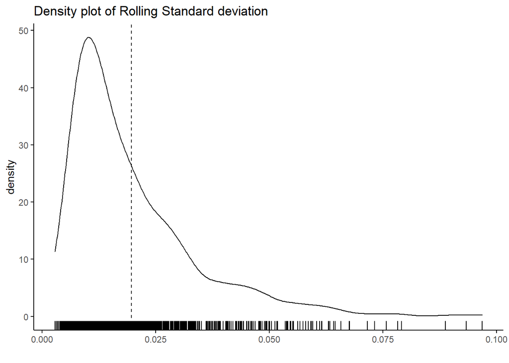

```
##
##  Shapiro-Wilk normality test
##
## data:  input_driver
## W = 0.84009, p-value < 2.2e-16
##
## [1] "Not normally distributed"
```

```r
# normality graph
normality <- function(input_driver, p_value) {

  print(ggdensity(input_driver,
          main = "Density plot of Rolling Standard deviation",
          xlab = "",
          add = 'mean',
          ggtheme = theme_classic(),
          rug = TRUE))

  z <- shapiro.test(input_driver)
  print(shapiro.test(input_driver))

  if(z[2]>= p_value){
    print('Normally Distributed')
    x <<- sys.call()
    x <<- as.character(x)
    norm_lst <<- append(norm_lst, x)
  }
  else{
    print('Not normally distributed')
  }
}

# function call
normality(final_drivers$roll_std_dev, 0.05)
```

If the result of the p-value is higher or equal to the passed p-value, the name of the variable is saved on `norm_lst` and stored in a meta data object. Usually, p-value <= 0.05 means that the distribution is significantly different than normal distribution.

2. Stationarity test
- Augmented Dickey-Fuller (ADF) t-statistic is used to find if the series has a unit root (a series with a trend line will have a unit root and result in a large p-value). If the p-value < 0.05 then data is stationary if p-value > 0.05 then data is non-stationary.

Before the test, we remove NA values and replace them with 0.

```r
# Stationarity check

stationarity <- function(input_driver, p_value) {
  input_driver[is.na(input_driver)] <- 0
  tseries::adf.test(input_driver)
  sz <- tseries::adf.test(input_driver)

    if(sz[2]<= p_value){
    y <<- sys.call()
    y <<- as.character(y)
    stat_lst <<- append(norm_lst, y)
    print(sz)
    print('Stationary Data')
  }
  else{
    print(sz)
    print('Non-stationary Data')
  }

}

# function call
stationarity(final_drivers$roll_mean, 0.05)
```

```
##
##  Augmented Dickey-Fuller Test
##
## data:  input_driver
## Dickey-Fuller = -1.7106, Lag order = 9, p-value = 0.7008
## alternative hypothesis: stationary
##
## [1] "Non-stationary Data"
```

- To test another drivers, just replace the input_driver. The data is also stored in a metadata object

```r
# saving normal data in metadata_normality.csv
try(lapply(norm_lst, function(x) write.table( data.frame(x), 'metadata_normality.csv'  , append= T, sep=',' )), silent = TRUE)

# saving stationary data in stationary_normality.csv
try(lapply(stat_lst, function(x) write.table( data.frame(x), 'metadata_stationary.csv'  , append= T, sep=',' )), silent = TRUE)
```

3. Correlation coefficient with the target

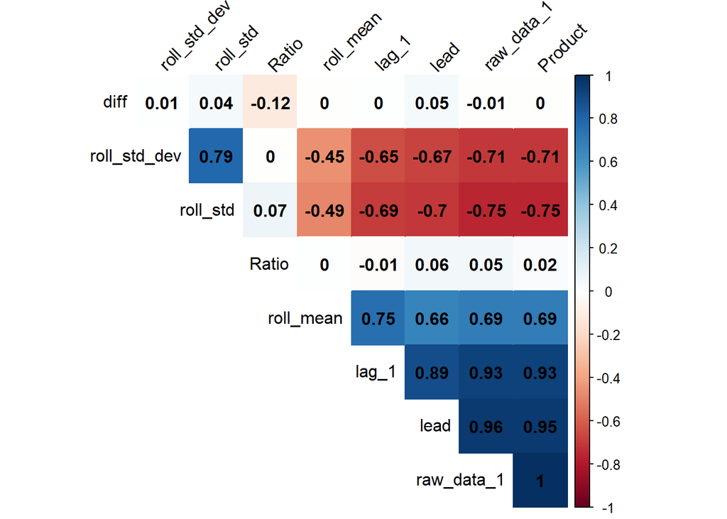

```r
# Correlation coefficient
correlation <- function(input_drivers){

  input_drivers[is.na(input_drivers)] <- 0
  corr_mat=cor(input_drivers)
col <- colorRampPalette(c("#BB4444", "#EE9988", "#FFFFFF", "#77AADD", "#4477AA"))
  return(corrplot(corr_mat, method="color",
         type="upper", order="hclust",
         addCoef.col = "black",
         tl.col="black", tl.srt=45,
         # hide correlation coefficient on the principal diagonal
         diag=FALSE
         ))

}

correlation(final_drivers)
```